# **Nitinat in-season update**

Last update: 2026-01-07

# 1 **2025 Pre-season forecasts and regs**

- Chinook: 21,000 (16,000 - 28,000)
- Chum: 139,985 (136,024 - 142,583)
- Coho:
  - Hatchery: Marine survival 5.5% (up from 2024) = Low marine survival
  - Wild: Marine survival 0.9% (same as 2024) = Critical status

Wild Coho is non-retention in Nitinat for 2025. 2/day for hatchery Coho Aug 25-Dec 1.

Chinook retention Aug 25-Sept 30, 2/day, only one >77cm.

Chum retention Aug 25-Sept 30 and Oct 16-Dec 31, 2/day.

Non-retention for SK.

No fishing u/s of Parker Creek. No fishing at bridge, hatchery, or Red Rock.

https://www.pac.dfo-mpo.gc.ca/fm-gp/rec/fresh-douce/region1-eng.html

## 1.1 Brood year escapements

The table below outlines the spawning escapement for brood year(s) that contributed to the 2025 return by species. Also important to consider are the hatchery egg/release targets and whether or not they were met. Note that in most years “Adult Broodstock Removals” includes culls/morts/surplus/“other uses” fish as well as the actual spawned broodstock.

| waterbody_name | species | year | 2025 age class | Adult Broodstock Removals | Natural Adult Spawners |
| --- | --- | --- | --- | --- | --- |
| NITINAT RIVER | Chinook | 2022 | 3 | 2699 | 11752 |
| NITINAT RIVER | Chinook | 2021 | 4 | 10370 | 13740 |
| NITINAT RIVER | Chinook | 2020 | 5 | 15823 | 14159 |
| NITINAT RIVER | Chum | 2022 | 3 | 8261 | 28783 |
| NITINAT RIVER | Chum | 2021 | 4 | 3342 | 65398 |
| NITINAT RIVER | Chum | 2020 | 5 | 31834 | 115688 |
| NITINAT RIVER | Coho | 2022 | 3 | 208 | 1258 |
| NITINAT RIVER | Sockeye | 2021 | 4 | 0 | 277 |

# 2 **In-season counts**

| NAME | Date | Segment(s) surveyed |
| --- | --- | --- |
| CAMPUS CREEK | 2025-10-29 | Upper |
| FAIRY CREEK | 2025-11-25 | Upper |
| FALLS CREEK | 2025-11-26 | Upper |
| HOBITON CREEK | 2025-04-30 | Upper |
| HOBITON CREEK | 2025-05-28 | Upper |
| HOBITON CREEK | 2025-06-17 | Upper |
| HOBITON CREEK | 2025-10-07 | Upper |
| JORDAN RIVER | 2025-11-13 | Upper |
| KLANAWA RIVER | 2025-09-22 | Upper |
| KLANAWA RIVER | 2025-10-10 | Upper |
| KLANAWA RIVER | 2025-11-12 | Upper |
| LITTLE NITINAT RIVER | 2025-10-21 | Upper |
| MOSQUITO CREEK | 2025-11-26 | Upper |
| NITINAT RIVER | 2025-08-26 | Lower |
| NITINAT RIVER | 2025-09-12 | Lower |
| NITINAT RIVER | 2025-09-12 | Upper |
| NITINAT RIVER | 2025-09-25 | Lower |
| NITINAT RIVER | 2025-09-25 | Upper |
| NITINAT RIVER | 2025-10-08 | Lower |
| NITINAT RIVER | 2025-10-08 | Upper |
| NITINAT RIVER | 2025-10-16 | Lower |
| NITINAT RIVER | 2025-10-16 | Upper |
| NITINAT RIVER | 2025-10-21 | Upper |
| NITINAT RIVER | 2025-11-04 | Lower |
| NITINAT RIVER | 2025-11-04 | Upper |

Peak counts (excluding trout):

Table 2.1: Total live adults observed by survey location and date. Peak count ‘Y’ indicates entry is the peak count observed for a given species as of current data available

| System | Date | Species | Survey method | Total adults live | Peak count |
| --- | --- | --- | --- | --- | --- |
| CAMPUS CREEK | 2025-10-29 | Chum | Snorkel | 103 |  |
| CAMPUS CREEK | 2025-10-29 | Coho | Snorkel | 3 |  |
| FAIRY CREEK | 2025-11-25 | Coho | Snorkel | 17 |  |
| FALLS CREEK | 2025-11-26 | Coho | Snorkel | 7 |  |
| HOBITON CREEK | 2025-04-30 | Sockeye | Snorkel | 0 |  |
| HOBITON CREEK | 2025-05-28 | Sockeye | Snorkel | 8 |  |
| HOBITON CREEK | 2025-06-17 | Sockeye | Snorkel | 2500 | Y |
| HOBITON CREEK | 2025-10-07 | Chinook | Snorkel | 6 |  |
| HOBITON CREEK | 2025-10-07 | Chum | Snorkel | 535 |  |
| JORDAN RIVER | 2025-11-13 | Coho | Snorkel | 31 |  |
| KLANAWA RIVER | 2025-10-10 | Chinook | Snorkel | 37 |  |
| KLANAWA RIVER | 2025-10-10 | Chum | Snorkel | 14 |  |
| KLANAWA RIVER | 2025-10-10 | Coho | Snorkel | 678 |  |
| KLANAWA RIVER | 2025-11-12 | Coho | Snorkel | 1 |  |
| LITTLE NITINAT RIVER | 2025-10-21 | Chum | FLAG | 22 |  |
| MOSQUITO CREEK | 2025-11-26 | Coho | Snorkel | 4 |  |
| NITINAT RIVER | 2025-08-26 | Chinook | Snorkel | 156 |  |
| NITINAT RIVER | 2025-08-26 | Coho | Snorkel | 1 |  |
| NITINAT RIVER | 2025-08-26 | Sockeye | Snorkel | 463 |  |
| NITINAT RIVER | 2025-08-26 | Steelhead | Snorkel | 17 | Y |
| NITINAT RIVER | 2025-09-12 | Chinook | Snorkel | 2867 |  |
| NITINAT RIVER | 2025-09-12 | Chum | Snorkel | 79 |  |
| NITINAT RIVER | 2025-09-12 | Coho | Snorkel | 109 |  |
| NITINAT RIVER | 2025-09-12 | Pink | Snorkel | 4 | Y |
| NITINAT RIVER | 2025-09-12 | Sockeye | Snorkel | 751 |  |
| NITINAT RIVER | 2025-09-12 | Steelhead | Snorkel | 8 |  |
| NITINAT RIVER | 2025-09-25 | Chinook | Snorkel | 3756 |  |
| NITINAT RIVER | 2025-09-25 | Chum | Snorkel | 391 |  |
| NITINAT RIVER | 2025-09-25 | Coho | Snorkel | 209 |  |
| NITINAT RIVER | 2025-09-25 | Sockeye | Snorkel | 482 |  |
| NITINAT RIVER | 2025-09-25 | Steelhead | Snorkel | 16 |  |
| NITINAT RIVER | 2025-10-08 | Chinook | Snorkel | 3906 | Y |
| NITINAT RIVER | 2025-10-08 | Chum | Snorkel | 5462 |  |
| NITINAT RIVER | 2025-10-08 | Coho | Snorkel | 1089 |  |
| NITINAT RIVER | 2025-10-08 | Sockeye | Snorkel | 362 |  |
| NITINAT RIVER | 2025-10-08 | Steelhead | Snorkel | 14 |  |
| NITINAT RIVER | 2025-10-16 | Chinook | Snorkel | 1126 |  |
| NITINAT RIVER | 2025-10-16 | Chum | Snorkel | 5334 |  |
| NITINAT RIVER | 2025-10-16 | Coho | Snorkel | 3365 | Y |
| NITINAT RIVER | 2025-10-16 | Sockeye | Snorkel | 308 |  |
| NITINAT RIVER | 2025-10-16 | Steelhead | Snorkel | 10 |  |
| NITINAT RIVER | 2025-10-21 | Chinook | Heli | 53 |  |
| NITINAT RIVER | 2025-10-21 | Chum | Heli | 24370 | Y |
| NITINAT RIVER | 2025-11-04 | Chum | Snorkel | 862 |  |
| NITINAT RIVER | 2025-11-04 | Coho | Snorkel | 713 |  |
| NITINAT RIVER | 2025-11-04 | Sockeye | Snorkel | 1 |  |

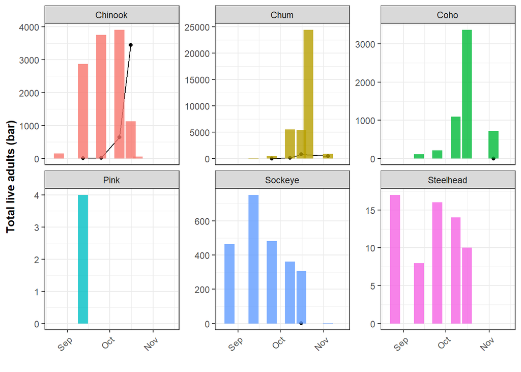

Figure 2.1: Raw live (bar) and carcass (line) counts for Nitinat River. Not all surveys are full system: early surveys are lower river only. Dead counts will populate once die-off begins.Note differing y-axis for each species.

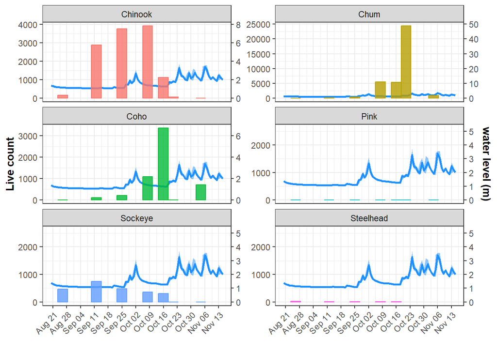

Figure 2.2: Live counts (bars) and water level (blue line) in the Nitinat River.

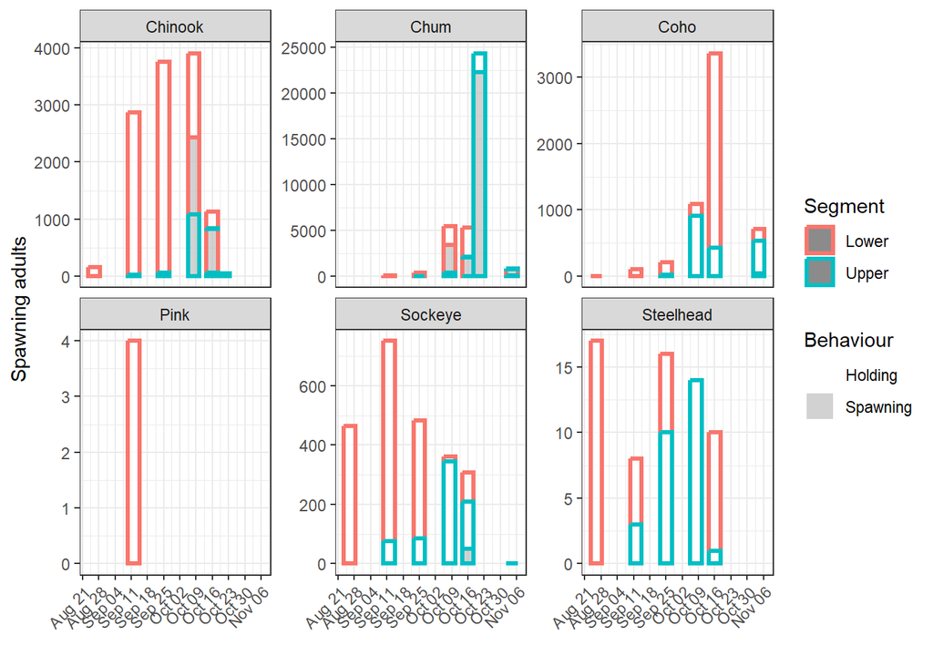

Figure 2.3: Spawning and holding behaviour for each species split by whether they were observed in the upper or lower Nitinat.

# 3 **Historical run timing**

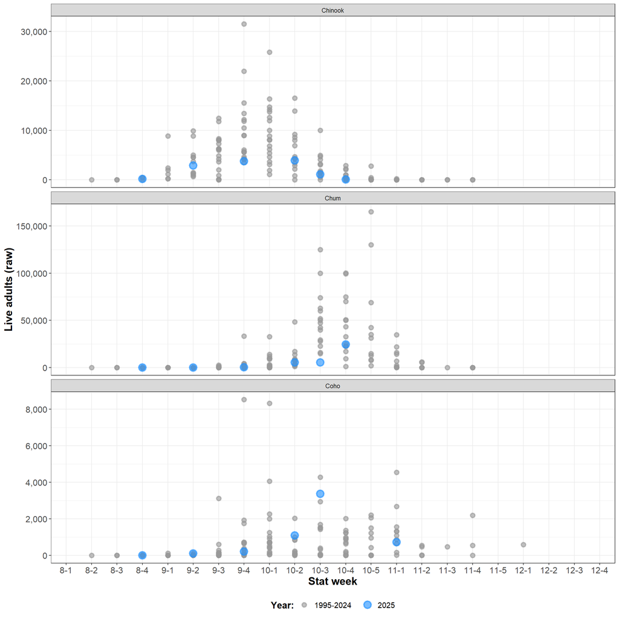

Figure 3.1: Historical run timing for focal species in Nitinat River (gray). Stat weeks along x axis denote the month and week of historical counts (e.g., stat week 8-1=First week of August, statweek 9-3=Third week of Sept, etc). Current year counts will show as blue points when populated.

# 4 **Water level and temperature**

The following water data are compiled from the Nitinat Hydromet operated by South Coast Stock Assessment: http://pacfish.ca/wcviweather/Content%20Pages/Nitinat/WaterLevel.aspx

The hydromet station for Nitinat is not currently reporting to the website. Work is underway to restore reporting before swims begin. For now, the following information is summarized from the backend database. Contact Katie with questions.

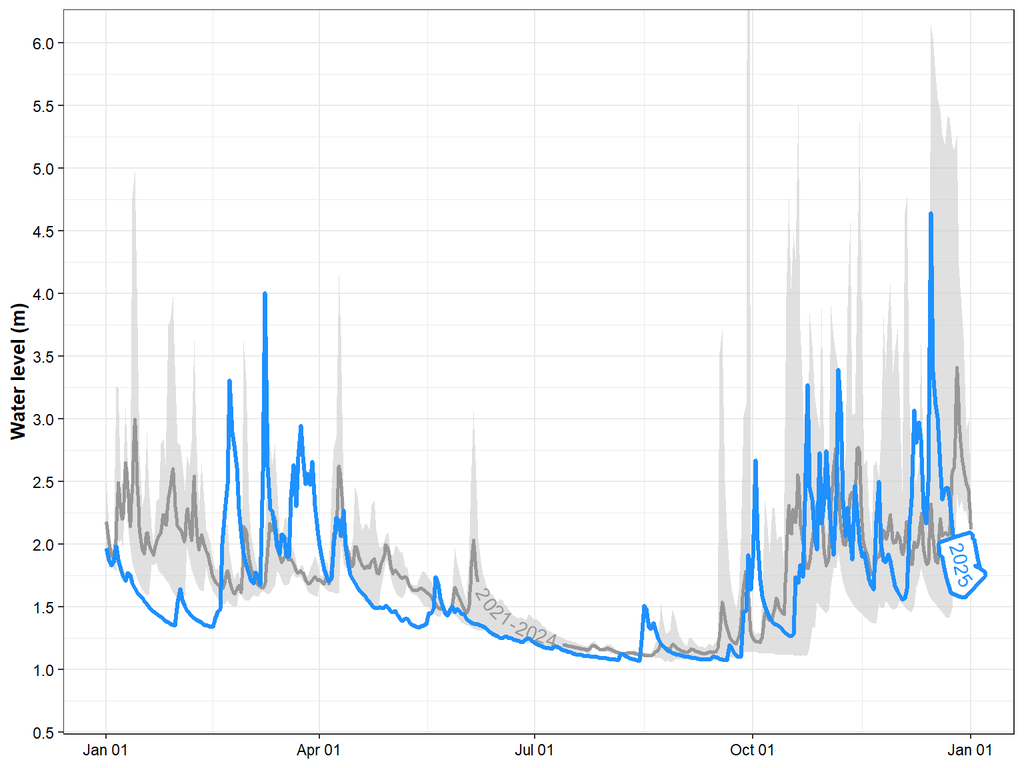

Figure 4.1: Nitinat hydromet water level (m). Historical shaded area represents daily maximum and minimum recorded values over the time series, while the line represents the mean water level. Current year line represents daily mean water level (blue). Water level is recorded hourly at the Nitinat River Hatchery pumphouse.

The last downloaded water level was **1.69 m** on **31-Dec-25** at **12:00 PM**. Current water temp is **6.89 C**, air temp is **3.37 C**.

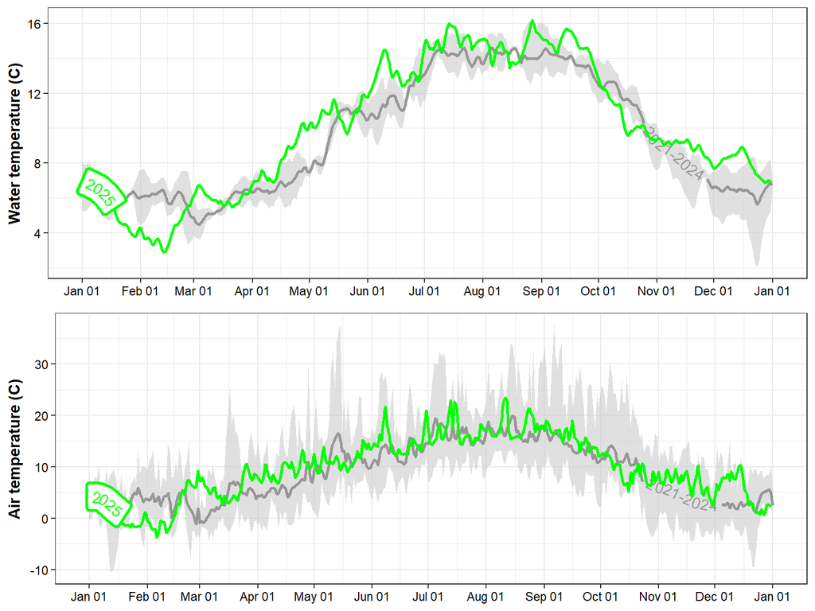

Figure 4.2: Nitinat hydromet water and air temperature (C). Historical shaded area represents daily maximum and minimum recorded values over the time series, while the line represents the mean (gray). Current year line represents daily mean water and/or air temperature (green). Water and air temperature are recorded hourly at the Nitinat River Hatchery pumphouse.

## 4.1 Summer water conditions

Graphs focusing on the lead up to and including peak salmon periods. Notable events included two lake turnover events this year, one on Sept 17 and the other Oct 14. On Sept 17 the hatchery lost all Chinook brood held in lake pens (~2800). The second turnover may have just been partial but rotten egg smell was noted especially at top end of lake.

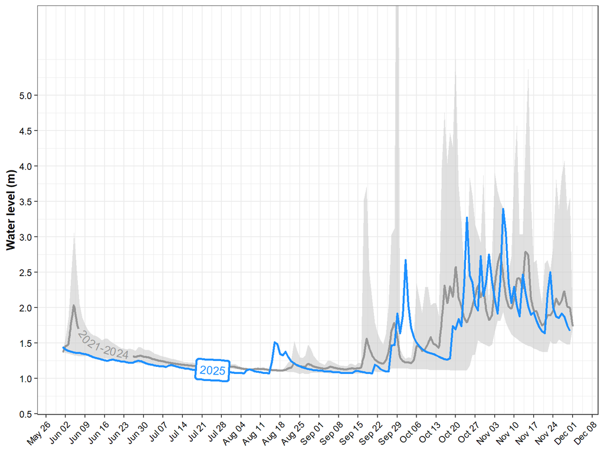

Figure 4.3: Nitinat hydromet water level (m) for summer and fall. Historical shaded area represents daily maximum and minimum recorded values over the time series, while the line represents the mean water level. Current year line represents daily mean water level (blue). Water level is recorded hourly at the Nitinat River Hatchery pumphouse.

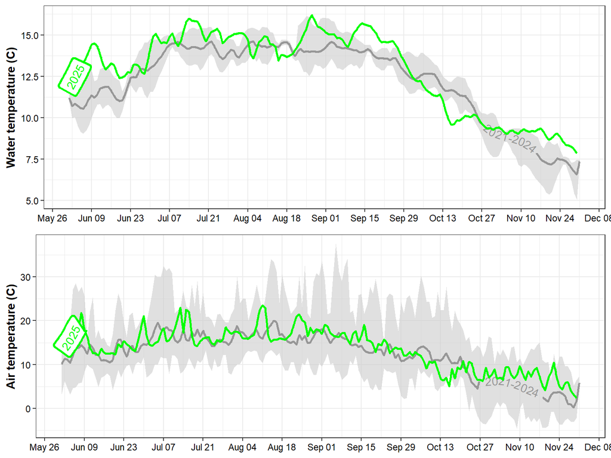

Figure 4.4: Nitinat hydromet water and air temperature (C) for summer and fall. Historical shaded area represents daily maximum and minimum recorded values over the time series, while the line represents the mean (gray). Current year line represents daily mean water and/or air temperature (green). Water and air temperature are recorded hourly at the Nitinat River Hatchery pumphouse.

## 4.2 Environment Canada river forecast

While there is no official flow forecast for the Nitinat River, the San Juan River Environment Canada COFFEE forecast can be used as a proxy for Nitinat River as both systems exhibit similar seasonal flow patterns.

[interactive chart not shown]

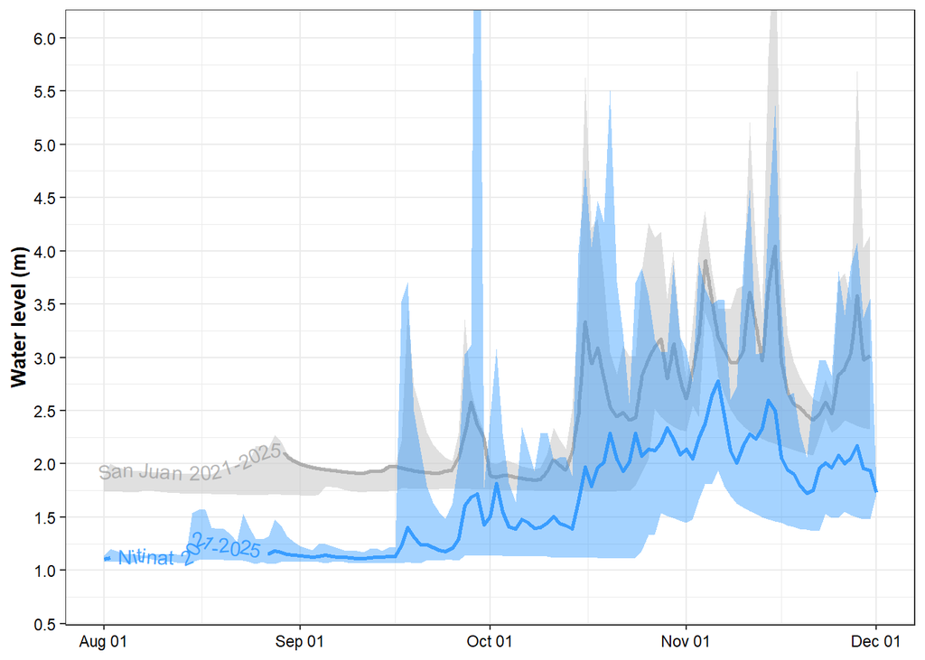

Figure 4.5: Summer/fall water level at Nitinat (blue) and San Juan (gray) from 2021-present. Shaded region represents daily maximum and minimum levels while solid line indicates daily average among all years. San Juan water level from Environment Canada, Nitinat from South Coast Stock assessment hydromet.

## 4.3 Weather forecast

[interactive chart not shown]

```
## [1] TRUE
```